# Regression on small dataset

Michalina Cieslak and Maciej Switala

03/02/2020

# 1 Introduction

The project was prepared for Machine Learning 2 classes. It covers the topic of regression methods on small dataset. We perform different models:

- linear regression (as a benchmark),
- stepwise regression,
- Ridge regression,
- Lasso regression,
- regrssion tree,
- kNN regression,

which will be compared based on the RMSE and R2 values.

# 2 Overview of the problem

Our dataset is retrived from: https://archive.ics.uci.edu/ml/datasets/Automobile. It referes to cars - describing their main features like, for example, model or number of doors. More precisely, it consists of 205 observations and 26 variables, which can be described as follows:

- car_ID - unique value of each observation
- symboling - assigned insurance risk rating, A value of +3 indicates that the car is risky, -3 that it is probably pretty safe.
- CarName - name of the car (including the model), i.e. audi 100ls
- fueltype - type of fuel, i.e. gas
- aspiration - aspiration used in a car
- doornumber - number of doors (two or four)
- carbody - frame of the car, i.e. hatchback
- drivewheel - type of drive, i.e. fwd (front-wheel drive)
- enginelocation - front or rear
- wheelbase - distance between the centers of the front and rear wheels (in inches)
- carlength - length of a car (in inches)
- carwidth - width of a car (in inches)
- carheight - height of a car (in inches)
- curbweight - the total mass of a vehicle with standard equipment and all necessary operating consumable (in pounds)
- enginetype - type of valvetrain, i.e. ohc
- cylindernumber - cylinder placed in a car
- enginesize - size of a car
- fuelsystem - type of fuel system, i.e. mpfi
- boreratio - boreratio of a car
- stroke - length of stroke (in inches)
- compressionratio - a ratio where you’re compressing the maximum cylinder volume into the minimum cylinder volume
- horsepower
- peakrpm - power band of an internal combustion engine or electric motor (in RPM)
- citympg - the lowest mpg rating
- highwaympg - the highest mpg rating
- price - price of the car

**Our goal is to see which of the proposed models work best in predicting the value of a car given its’ characteristics.**

# 3 Data summary

The dataset has no missing values. Since the column CarName consists of many unique values, we created new variable (CarBrand), which takes only the first word from the former one and simply gives an information about the brand of a car. Some of the variables were encoded as characters, thus, we changed them to factors - in a way, that there is at most 15 levels. Furthermore, in the process of data preparation, we removed two columns, car_ID and CarName, because they consisted of unique, or almost only unique, values. Since the number of observations is rather small, we decided not to remove outliers. Instead, in further analysis, we used robust standarization, which is resistant to them.

## 3.1 Dependent variable

Price is our dependent variable. As it can be noticed on the graph and statistics below, it is highly and postively skewed. Mean price of all observations equals to 13277, while the highest one is 45400 and is assigned to a buick regal sport coupe (turbo).

```r
cont <- data_final[,continuous_variables]
sum_pr <- round(basicStats(cont$price), 0)
sum_pr <- data.frame(t(sum_pr))
sum_pr <- sum_pr[,c(3,4,7,8,13,14,15,16)]
rownames(sum_pr) <- c('price')
kable(sum_pr) %>%
  kable_styling()
```

|  | Minimum | Maximum | Mean | Median | Variance | Stdev | Skewness | Kurtosis |
| --- | --- | --- | --- | --- | --- | --- | --- | --- |
| price | 5118 | 45400 | 13277 | 10295 | 63821762 | 7989 | 2 | 3 |

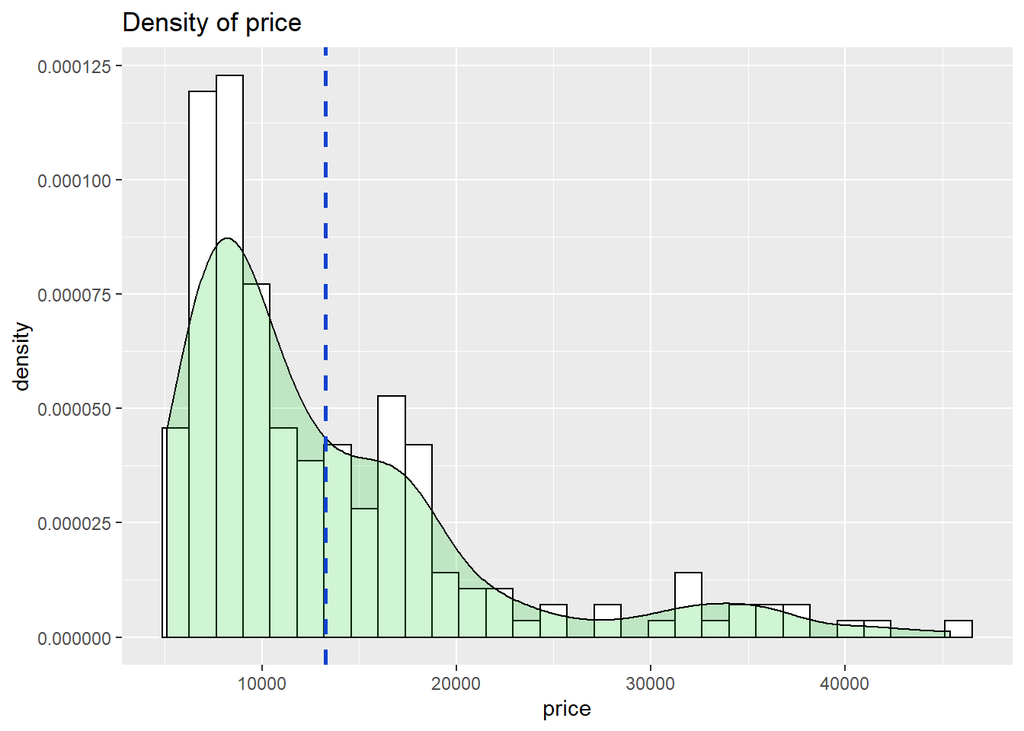

## 3.2 Independent variables

### 3.2.1 Continuous independent variables

There are 13 continuous independent variables. All of them have, more or less, same distribution, the points are rather concentrated, except Compressionratio, where most of the obesrvations are smaller than 12 and the rest is higher than 20.

|  | Mean | Stdev | Median | Minimum | Maximum |
| --- | --- | --- | --- | --- | --- |
| wheelbase | 99 | 6 | 97 | 87 | 121 |
| carlength | 174 | 12 | 173 | 141 | 208 |
| carwidth | 66 | 2 | 66 | 60 | 72 |
| carheight | 54 | 2 | 54 | 48 | 60 |
| curbweight | 2556 | 521 | 2414 | 1488 | 4066 |
| enginesize | 127 | 42 | 120 | 61 | 326 |
| boreratio | 3 | 0 | 3 | 3 | 4 |
| stroke | 3 | 0 | 3 | 2 | 4 |
| compressionratio | 10 | 4 | 9 | 7 | 23 |
| horsepower | 104 | 40 | 95 | 48 | 288 |
| peakrpm | 5125 | 477 | 5200 | 4150 | 6600 |
| citympg | 25 | 7 | 24 | 13 | 49 |
| highwaympg | 31 | 7 | 30 | 16 | 54 |

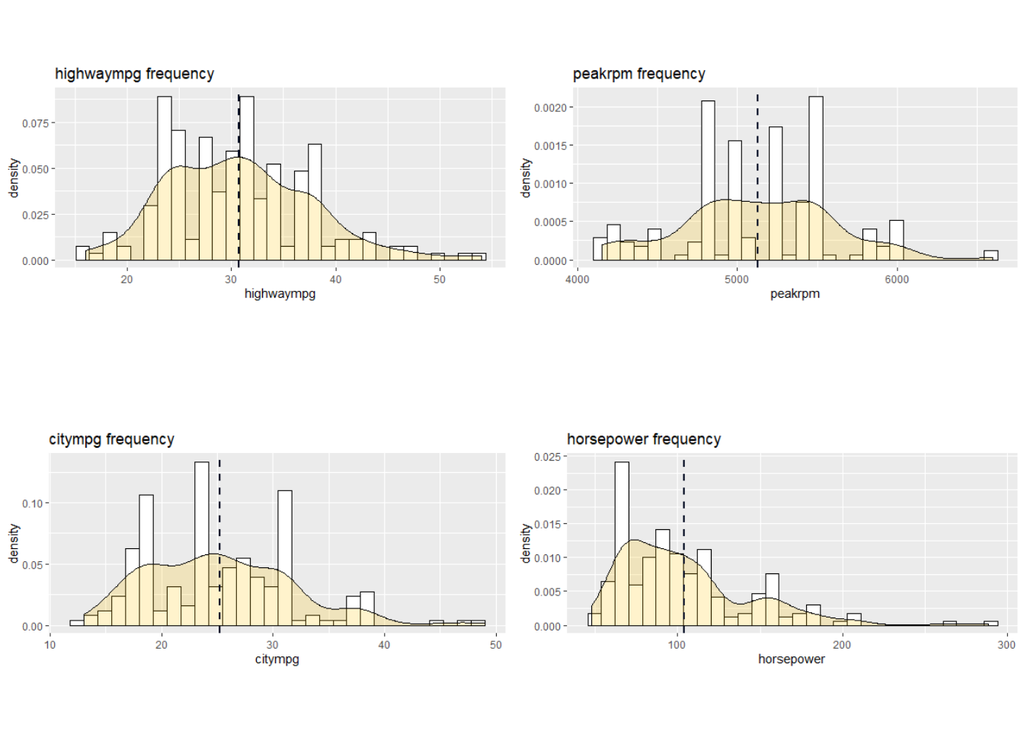

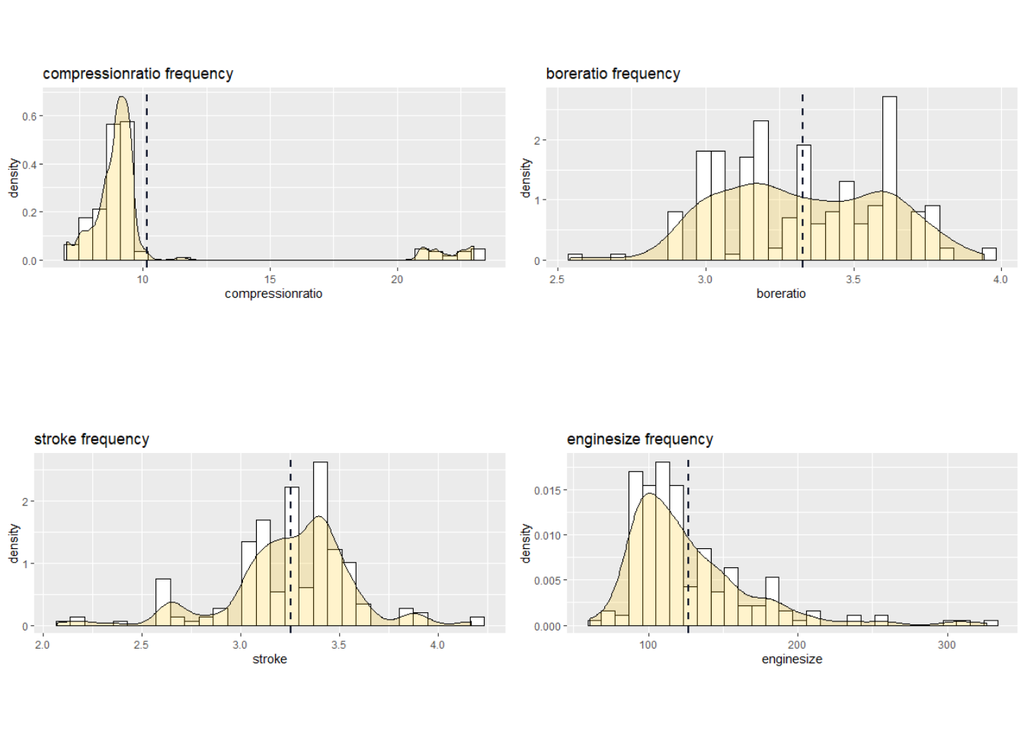

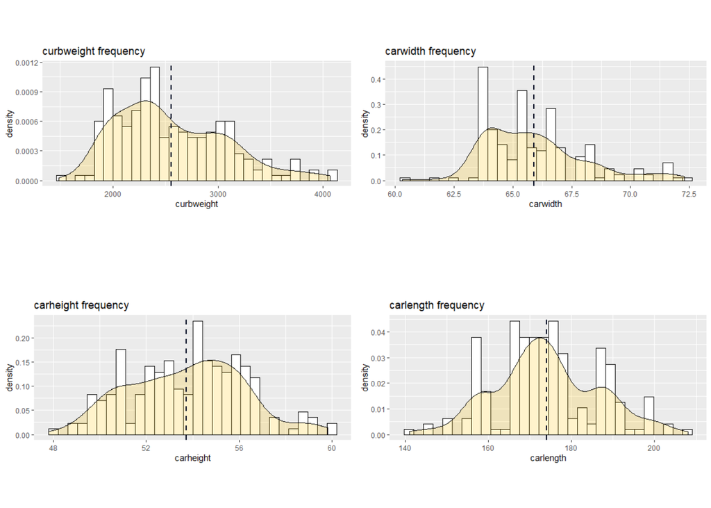

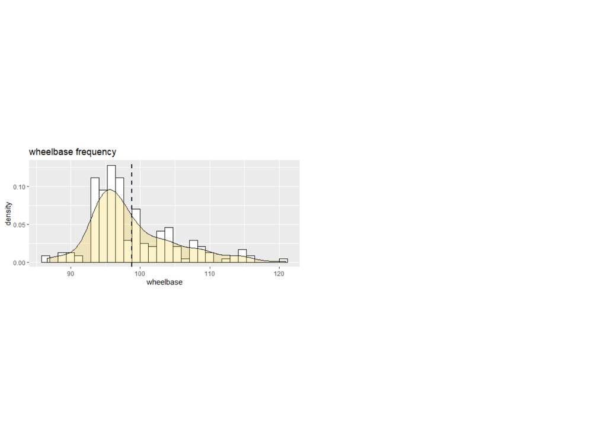

### 3.2.2 Categorical independent variables

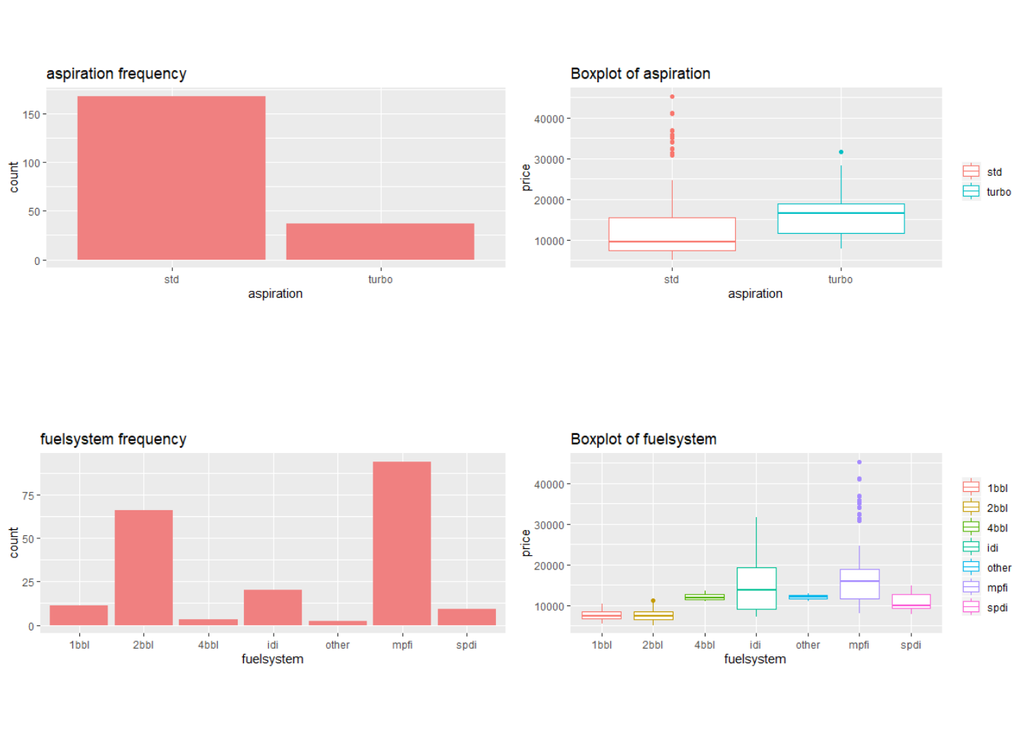

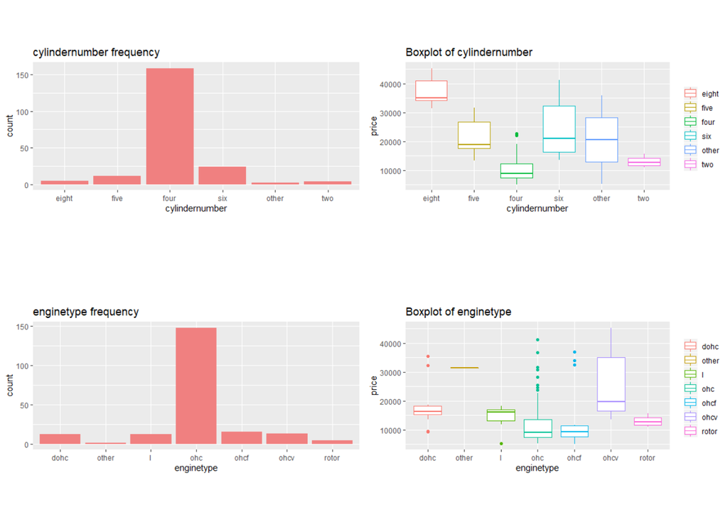

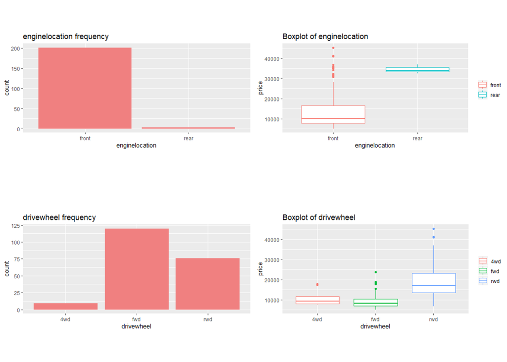

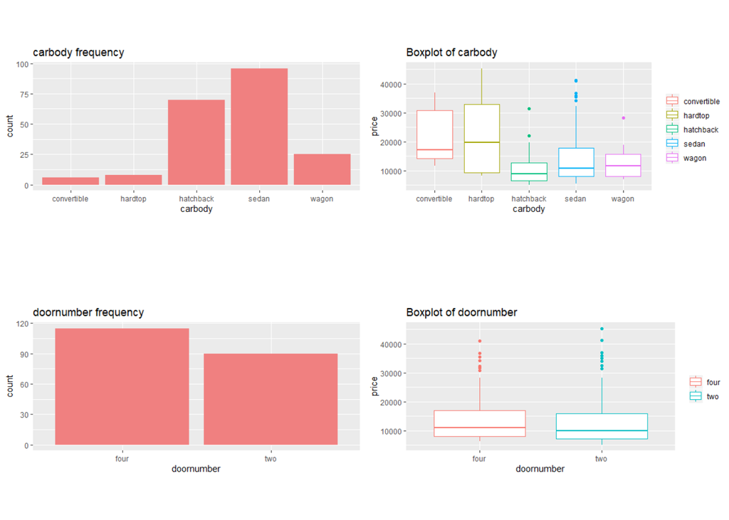

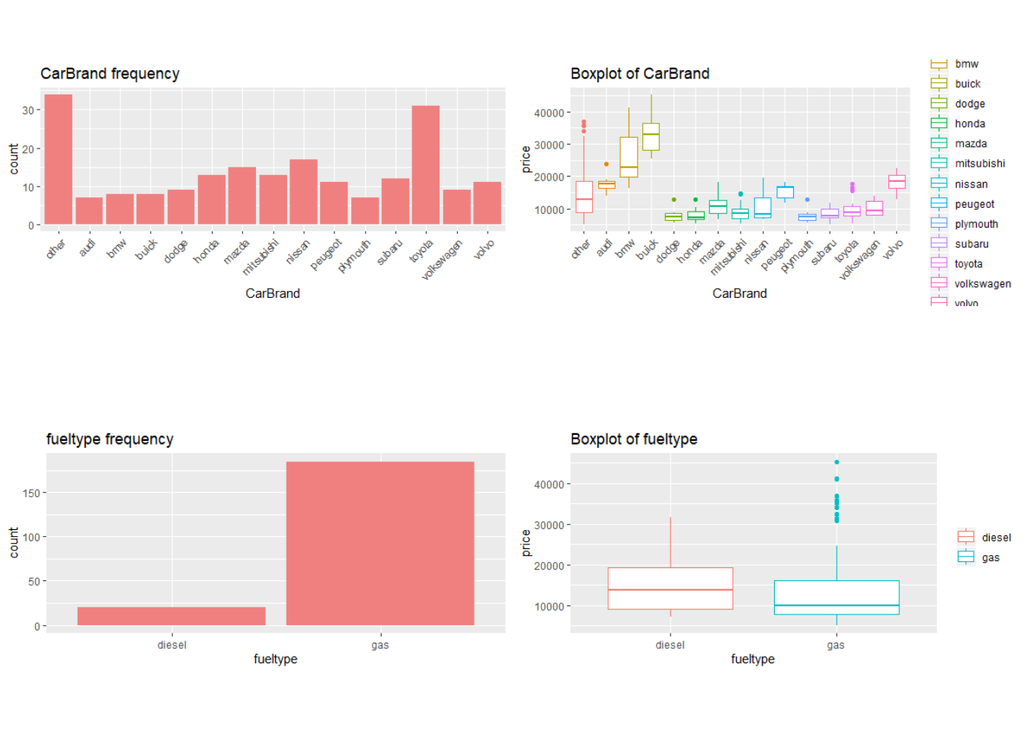

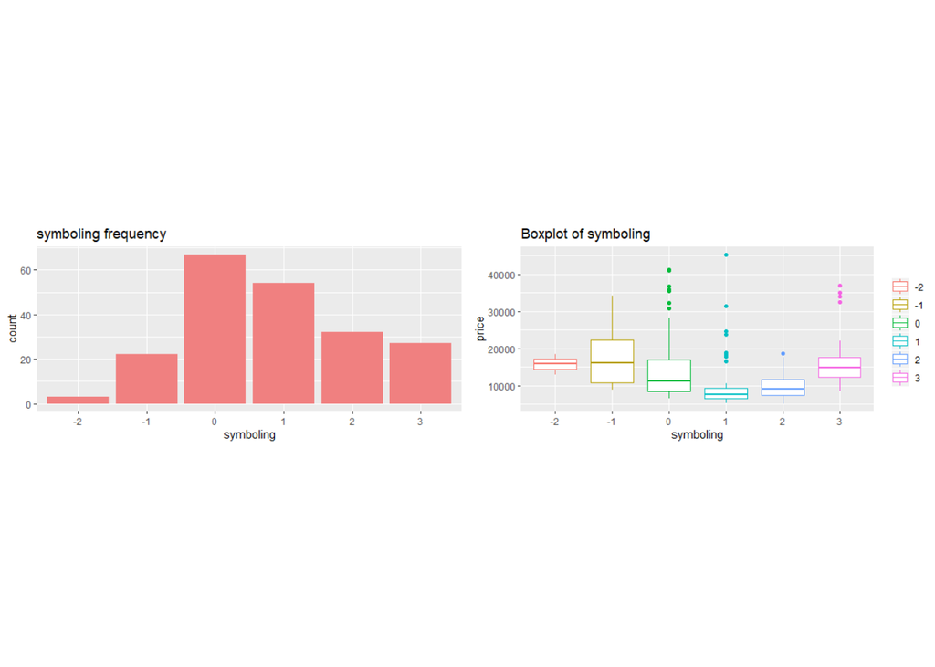

## 3.3 Correlations

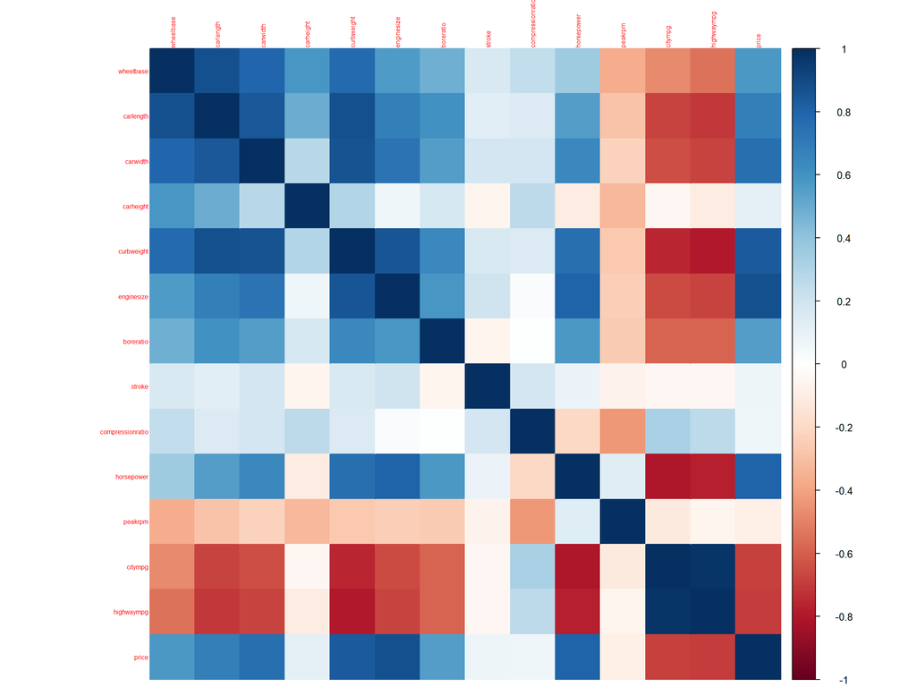

```r
#correlations' analyses
source('correlations_11.12.R')

#pearson for continuous variables
correlations(data_final,continuous_variables[,-14],1)
```

When it comes to categorical variables, beside carbody and doornumber, they show correlation at the level of 40% at maximum. The calculations were provided with the help of goodman-kruskal lambdas.

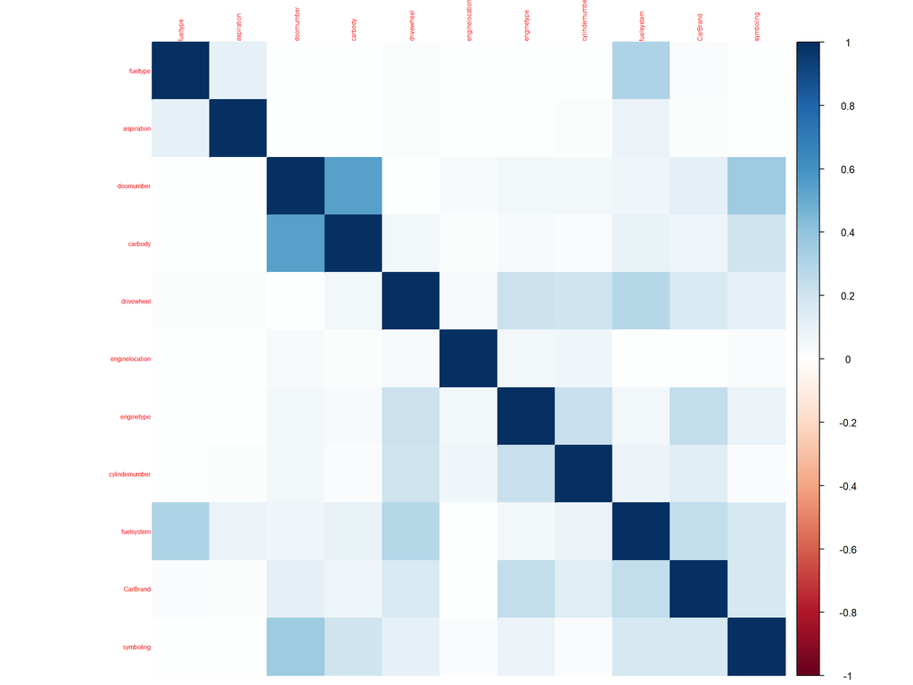

```r
#goodman/kruskal lambda for categorical variables
correlations(data_final,categorical_variables,0)
```

# 4 Data preparation

```r
data_final_enc <- as.data.frame(one_hot(as.data.table(data_final)))

data_final_enc_cont <- as.data.frame(one_hot(as.data.table(data_final[,continuous_variables])))

data_final_enc_cat <- as.data.frame(one_hot(as.data.table(data_final[,categorical_variables])))

#scaling dataset
data_final_enc_cont <- robustscale(data_final_enc_cont)

data_final_enc <- cbind(data_final_enc_cat, data_final_enc_cont$data)

data_final_enc <- data_final_enc %>%
  rename(
    symboling_neg_1 = 'symboling_-1',
    symboling_neg_2 = 'symboling_-2'
  )

set.seed(12345)
##split into train and test
indice = sample(seq_len(nrow(data_final_enc)), size = floor(0.7*nrow(data_final_enc)))

train = data_final_enc[indice,]
test = data_final_enc[-indice,]

c_5 = trainControl(method = "cv", number = 5)
```

# 5 Modelling

## 5.1 Linear regression

```r
#function from the classes
source('regressionMetrics.R')

modelform <- price~.
set.seed(12345)
linear <- train(modelform, data = train,
                method = "lm",
                metric = "RMSE",
                trControl = c_5)

linear$results
summary(linear)

predictions_l <- predict(linear, test)

linear_m <- regressionMetrics(real=test$price, predicted=predictions_l)
linear_m

set.seed(12345)
model1 <- lm(price~., data=train)
step.model <- stepAIC(model1, direction='both', trace=TRUE)

modelformula <- as.formula(step.model$call)

set.seed(12345)
linear_2 <- train(modelformula, data = train,
                method = "lm",
                metric = "RMSE",
                trControl = c_5)

linear_2$results
summary(linear_2)

predictions_l_2 <- predict(linear_2, test)

linear_m_2 <- regressionMetrics(real=test$price, predicted=predictions_l_2)
linear_m_2
```

Firstly, we ran a linear regression including all of the variables. Since, many of them are insignificant and the results on test data are rather poor, we performed stepwise regression. It tries different combinations and then, basing on the value of AIC, returns best final model. Since we wanted to chose the formula most precisely, we set option direction to both (checked forward and backward selection).

**price ~ aspiration_std + carbody_convertible + carbody_sedan + enginelocation_front + enginetype_dohc + enginetype_l + enginetype_ohc + enginetype_ohcf + enginetype_ohcv + cylindernumber_eight + cylindernumber_five + cylindernumber_four + cylindernumber_six + fuelsystem_2bbl + fuelsystem_mpfi + CarBrand_bmw + CarBrand_dodge + CarBrand_mitsubishi + CarBrand_plymouth + CarBrand_toyota + CarBrand_volkswagen + symboling_neg_2 + carlength + carwidth + curbweight + enginesize + boreratio + stroke + compressionratio + peakrpm**

After running the regression with respect to above formula, it turned out that all the variables, except symboling_neg_2 and carbody_sedan, are significant with at most 10%.

### 5.1.1 Results

The table below displays the results for both train and test sample for linear and stepwise regressions.

| **Model** | **Train Rsquared** | **Test Rsquared** | **Train RMSE** | **Test RMSE** |
| --- | --- | --- | --- | --- |
| *linear regression* | 86.47% | 39.97% | 289.38 | 397.69 |
| *stepwise regression* | 93.1% | 48.22% | 206.5 | 369.35 |

According to the results, stepwise regression slightly improved the performance on the test data. However, the model still poorly predicts the price (given R2 equal to 48.22%). For both regressions the difference between test and train R2 is very big, with the value of the former quite low and for the latter one high. This may be a result of overfitting. To deal with such a problem it might be worth trying to use Lasso or Ridge regression. When it comes to RMSE, the stepwise regression lowered it significantly, so that that the errors are smaller.

## 5.2 Ridge and Lasso regressions

```r
lambda <- 10^seq(-3, 3, length = 100)
set.seed(12345)
ridge <- train(
  price ~., data = train, method = "glmnet",
  trControl = c_5,
  tuneGrid = expand.grid(alpha = 0, lambda = lambda),
  standardize = FALSE
)

ridge$bestTune$lambda

predictions_r_tr <- ridge %>% predict(train) #, s=ridge$bestTune$lambda)
ridge_m_tr <- regressionMetrics(real=train$price, predicted=predictions_r_tr)
ridge_m_tr

predictions_r <- ridge %>% predict(test) #, s=ridge$bestTune$lambda)
ridge_m_tst <- regressionMetrics(real=test$price, predicted=predictions_r)
ridge_m_tst
####################
set.seed(12345)
lasso <- train(
  price ~., data = train, method = "glmnet",
  trControl = c_5,
  tuneGrid = expand.grid(alpha = 1, lambda = lambda),
  standardize = FALSE
)

lasso$bestTune$lambda

predictions_ls_tr <- lasso %>% predict(train)#, s=lasso$bestTune$lambda)
lasso_m_tr <- regressionMetrics(real=train$price, predicted=predictions_ls_tr)
lasso_m_tr

predictions_ls <- lasso %>% predict(test)#, s=lassso$bestTune$lambda)
lasso_m_tst <- regressionMetrics(real=test$price, predicted=predictions_ls)
lasso_m_tst
```

As mentioned before, we want to reduce the difference between statistics on test and train data, so that the model will explain higher percent of the variability of the response data around it’s mean. Firstly we ran Ridge, then Lasso regression. In both cases the lambda, which is simply the penalty, equals to 1000.

### 5.2.1 Results

The table below displays the results for both, train and test, samples for linear, Lasso and Ridge regressions.

| **Model** | **Train Rsquared** | **Test Rsquared** | **Train RMSE** | **Test RMSE** |
| --- | --- | --- | --- | --- |
| *linear regression* | 86.47% | 39.97% | 289.38 | 397.69 |
| *Ridge regression* | 85.97% | 76.63% | 284.64 | 248.13 |
| *Lasso regression* | 85.73% | 76.19% | 287.06 | 250.45 |

## 5.3 Regression tree

```r
set.seed(12345)
cars.tree_2 <- tree(price ~ ., train, mindev=0.001)

cars.cv_2 <- cv.tree(cars.tree_2, K = 5)

best.size_2 <- cars.cv_2$size[which(cars.cv_2$dev==min(cars.cv_2$dev))]
best.size_2

set.seed(12345)
cars.prune_2 <- prune.tree(cars.tree_2, best = best.size_2[length(best.size_2)])

cars.pred_2 <- predict(cars.tree_2, newdata = test)

cars.pred_2_tr <- predict(cars.tree_2, newdata = train)
tree_m_2_tr <- regressionMetrics(real=train$price, predicted=cars.pred_2_tr)
tree_m_2_tr

tree_m_2_tst <- regressionMetrics(real=test$price, predicted=cars.pred_2)
tree_m_2_tst
```

Furthermore, we decided to see how well our data can be predicted using regression tree. The result of best size of a tree after prunning equals to 6. We tried different values of mindev, the one that resulted in best metrics (relatively high R2 and low RMSE) equals to 0.001

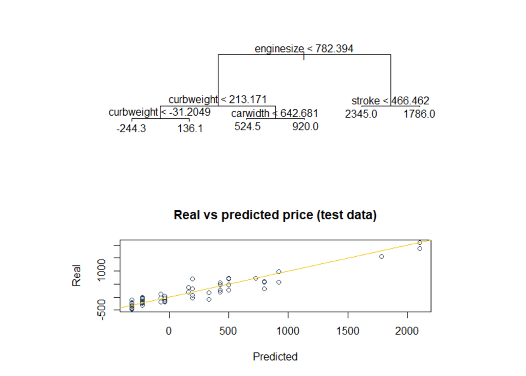

The first plot depicts the tree we obtained after prunning. It is hardly interpretable because of the previously standarized data. However, we can say that there are four constructions used - enginesize, curbweight, carwidth and stroke.The number of terminal nodes equals to 6. Since we want to focus more on the accuracy of the model, the second graph shows the relationship between predicted and real prices. It can be observed that it is rather linear. All of the points are close to the line, meaning that the prediction correlates with the true value.

### 5.3.1 Results

Regression tree, again, significantly improved the value of R2 compared to already performed methods. At the same time lowering RMSE for both - train and test data.

| **Model** | **Train Rsquared** | **Test Rsquared** | **Train RMSE** | **Test RMSE** |
| --- | --- | --- | --- | --- |
| *linear regression* | 86.47% | 39.97% | 289.38 | 397.69 |
| *regression tree* | 95.29% | 87.66% | 164.95 | 180.33 |

## 5.4 kNN regressions

```r
set.seed(12345)
knn1 <-
  train(price~.,
        data = train,
        method = "knn",
        trControl = c_5,
        standarize = FALSE,
        metric="RMSE")

knn1

knn1$finalModel
knn1$finalModel$k
knn1$bestTune$k

#knnPredict <- predict(knn1,newdata = train, s=knn1$bestTune$k)

predictions_knn_tr <- knn1 %>% predict(train)#, s=knn1$bestTune$k)
knn_m_tr <- regressionMetrics(real=train$price, predicted=predictions_knn_tr)
knn_m_tr

predictions_knn <- knn1 %>% predict(test)#, s=knn1$bestTune$k)
knn_m_tst <- regressionMetrics(real=test$price, predicted=predictions_knn)
knn_m_tst
```

The last regression we wanted to use is kNN. It assesses the value of the new data point based on the average of distances to the closests training points. According to the graph below, the number of neighbours that results in the smallest RMSE (and MAE) equals to 5.

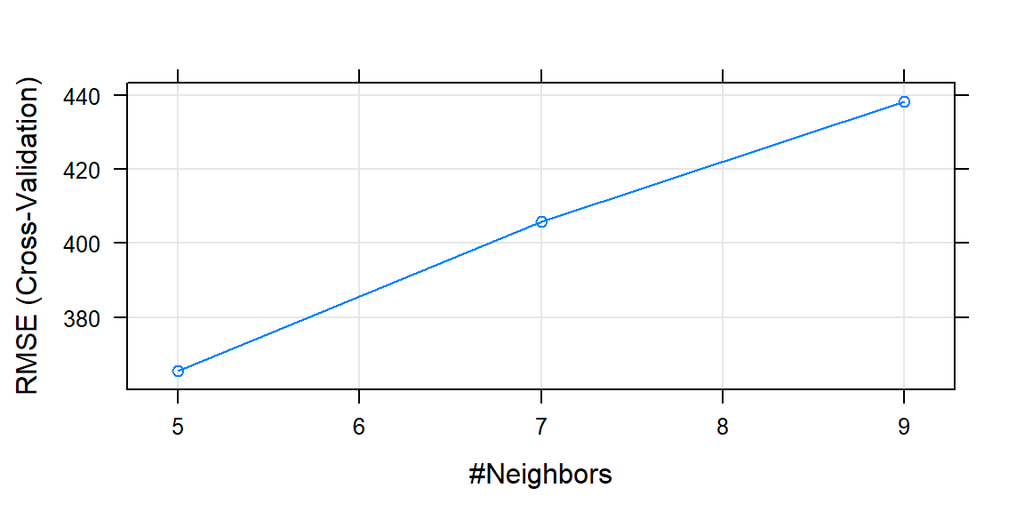

```r
plot(knn1)
```

### 5.4.1 Results

When it comes to R2, this type of regression is better than the linear and stepwise ones. However, there is the same problem with RMSE, that arised for Ridge and Lasso regression - train RMSE is higher than test.

| **Model** | **Train Rsquared** | **Test Rsquared** | **Train RMSE** | **Test RMSE** |
| --- | --- | --- | --- | --- |
| *linear regression* | 86.47% | 39.97% | 289.38 | 397.69 |
| *kNN regression* | 86.84% | 79.21% | 275.65 | 234.04 |

# 6 Conclusions

| **Model** | **Train Rsquared** | **Test Rsquared** | **Train RMSE** | **Test RMSE** |
| --- | --- | --- | --- | --- |
| *linear regression* | 86.47% | 39.97% | 289.38 | 397.69 |
| *stepwise regression* | 93.1% | 48.22% | 206.5 | 369.35 |
| *Ridge regression* | 85.97% | 76.63% | 284.64 | 248.13 |
| *Lasso regression* | 85.73% | 76.19% | 287.06 | 250.45 |
| *regression tree* | 95.29% | 87.66% | 164.95 | 180.33 |
| *kNN regression* | 86.84% | 79.21% | 275.65 | 234.04 |